# Reproducible Research: Peer Assessment 1

This is an R Markdown document for Course Project 1 from Coursera’s Reproducible Research.

This assignment makes use of data from a personal activity monitoring device. This device collects data at 5 minute intervals through out the day. The data consists of two months of data from an anonymous individual collected during the months of October and November, 2012 and include the number of steps taken in 5 minute intervals each day.

The data for this assignment can be downloaded from the course web site:

[Dataset: Activity monitoring data](https://d396qusza40orc.cloudfront.net/repdata%2Fdata%2Factivity.zip)

The dataset is stored in a comma-separated-value (CSV) file and there are a total of 17,568 observations in this dataset.

## Loading and preprocessing the data

1. Load the data

First I will read the data using a simple read.csv() and activating header.

```r
file <- read.csv("./activity.csv", header = TRUE)
```

Let’s see head and tail for the file to identify columns and data type:

```r
head(file)
```

```
##   steps       date interval
## 1    NA 2012-10-01        0
## 2    NA 2012-10-01        5
## 3    NA 2012-10-01       10
## 4    NA 2012-10-01       15
## 5    NA 2012-10-01       20
## 6    NA 2012-10-01       25
```

```r
tail(file)
```

```
##       steps       date interval
## 17563    NA 2012-11-30     2330
## 17564    NA 2012-11-30     2335
## 17565    NA 2012-11-30     2340
## 17566    NA 2012-11-30     2345
## 17567    NA 2012-11-30     2350
## 17568    NA 2012-11-30     2355
```

2. Process/transform the data (if necessary) into a format suitable for your analysis

Now let’s exclude NA values in ‘steps’ column. Then let’s see new head for cleaned file.

```r
fileClean <- file[!is.na(file$steps),]
head(fileClean)
```

```
##     steps       date interval
## 289     0 2012-10-02        0
## 290     0 2012-10-02        5
## 291     0 2012-10-02       10
## 292     0 2012-10-02       15
## 293     0 2012-10-02       20
## 294     0 2012-10-02       25
```

## What is mean total number of steps taken per day?

For this part of the assignment I will ignore the missing values in the dataset.

1. Calculate the total number of steps taken per day Let’s use function aggregate to sum (FUN = sum) ‘steps’ column based on ‘date’ column.

```r
fileSum <- aggregate(fileClean$steps, by = list(fileClean$date), FUN = sum)
names(fileSum) <- c("date","steps")
print(fileSum)
```

```
##          date steps
## 1  2012-10-02   126
## 2  2012-10-03 11352
## 3  2012-10-04 12116
## 4  2012-10-05 13294
## 5  2012-10-06 15420
## 6  2012-10-07 11015
## 7  2012-10-09 12811
## 8  2012-10-10  9900
## 9  2012-10-11 10304
## 10 2012-10-12 17382
## 11 2012-10-13 12426
## 12 2012-10-14 15098
## 13 2012-10-15 10139
## 14 2012-10-16 15084
```

[output cut: 39 more lines]

2. If you do not understand the difference between a histogram and a barplot, research the difference between them. Make a histogram of the total number of steps taken each day Now I will print an histogram with hist() function based on ‘steps’ column.

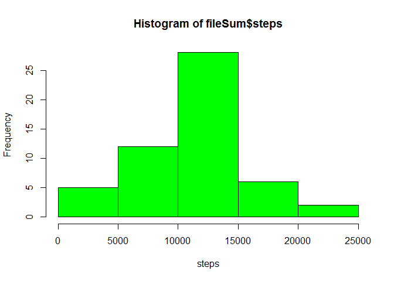

```r
hist(fileSum$steps, col ="green", xlab="steps")
```

3. Calculate and report the mean and median of the total number of steps taken per day Let’s include a table for each measure in the same way we did for SUM in point 1.

```r
aggregate(fileClean$steps, by = list(fileClean$date), FUN = mean)
```

```
##       Group.1          x
## 1  2012-10-02  0.4375000
## 2  2012-10-03 39.4166667
## 3  2012-10-04 42.0694444
## 4  2012-10-05 46.1597222
## 5  2012-10-06 53.5416667
## 6  2012-10-07 38.2465278
## 7  2012-10-09 44.4826389
## 8  2012-10-10 34.3750000
## 9  2012-10-11 35.7777778
## 10 2012-10-12 60.3541667
## 11 2012-10-13 43.1458333
## 12 2012-10-14 52.4236111
## 13 2012-10-15 35.2048611
## 14 2012-10-16 52.3750000
```

[output cut: 39 more lines]

```r
aggregate(fileClean$steps, by = list(fileClean$date), FUN = median)
```

```
##       Group.1 x
## 1  2012-10-02 0
## 2  2012-10-03 0
## 3  2012-10-04 0
## 4  2012-10-05 0
## 5  2012-10-06 0
## 6  2012-10-07 0
## 7  2012-10-09 0
## 8  2012-10-10 0
## 9  2012-10-11 0
## 10 2012-10-12 0
## 11 2012-10-13 0
## 12 2012-10-14 0
## 13 2012-10-15 0
## 14 2012-10-16 0
```

[output cut: 39 more lines]

## What is the average daily activity pattern?

*Make a time series plot (i.e. type = “l”) of the 5-minute interval (x-axis) and the average number of steps taken, averaged across all days (y-axis)

For plotting let’s load library ggplot2

```r
library(ggplot2)
```

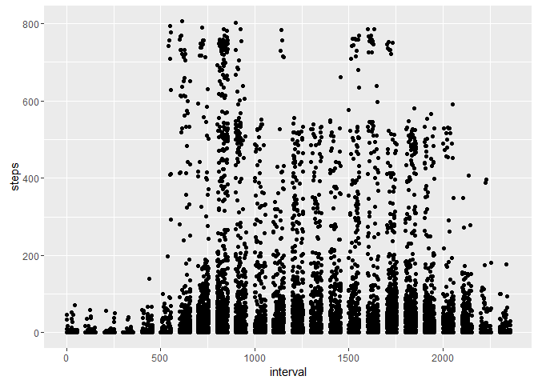

```r
qplot(interval, steps, data = fileClean)
```

*Which 5-minute interval, on average across all the days in the dataset, contains the maximum number of steps?

I will create a new table containing the row with the highest ‘steps’ value (maximum).

```r
fileMax <- fileClean[which(fileClean[,"steps"]==max(fileClean$steps)),]
head(fileMax)
```

```
##       steps       date interval
## 16492   806 2012-11-27      615
```

Then lets extract the value from the question:

```r
fileMax$interval
```

```
## [1] 615
```

## Imputing missing values

Note that there are a number of days/intervals where there are missing values (coded as NA). The presence of missing days may introduce bias into some calculations or summaries of the data.

1. Calculate and report the total number of missing values in the dataset (i.e. the total number of rows with NAs)

I will use a sum to calculate all values showing TRUE (value 1) to validation if it is NA with is.na function

```r
sum(is.na(file$steps))
```

```
## [1] 2304
```

2. Devise a strategy for filling in all of the missing values in the dataset. The strategy does not need to be sophisticated. For example, you could use the mean/median for that day, or the mean for that 5-minute interval, etc.

```r
newSteps <- aggregate(fileClean$steps, by = list(fileClean$interval), FUN = mean)
names(newSteps) <- c("interval","stepsMean")
head(newSteps)
```

```
##   interval stepsMean
## 1        0 1.7169811
## 2        5 0.3396226
## 3       10 0.1320755
## 4       15 0.1509434
## 5       20 0.0754717
## 6       25 2.0943396
```

3. Create a new dataset that is equal to the original dataset but with the missing data filled in.

And now lets join column stepsMean to the main table in a new variable called ‘fileCompleted’

```r
fileCompleted <- merge(file,newSteps,by.x="interval", by.y="interval")
head(fileCompleted)
```

```
##   interval steps       date stepsMean
## 1        0    NA 2012-10-01  1.716981
## 2        0     0 2012-11-23  1.716981
## 3        0     0 2012-10-28  1.716981
## 4        0     0 2012-11-06  1.716981
## 5        0     0 2012-11-24  1.716981
## 6        0     0 2012-11-15  1.716981
```

Now lets create a new column containing newSteps (for NA replace steps with stepsMean column)

```r
fileCompleted$newSteps <- ifelse(is.na(fileCompleted$steps),fileCompleted$stepsMean,fileCompleted$steps)
head(fileCompleted)
```

```
##   interval steps       date stepsMean newSteps
## 1        0    NA 2012-10-01  1.716981 1.716981
## 2        0     0 2012-11-23  1.716981 0.000000
## 3        0     0 2012-10-28  1.716981 0.000000
## 4        0     0 2012-11-06  1.716981 0.000000
## 5        0     0 2012-11-24  1.716981 0.000000
## 6        0     0 2012-11-15  1.716981 0.000000
```

```r
tail(fileCompleted)
```

```
##       interval steps       date stepsMean newSteps
## 17563     2355     0 2012-10-16  1.075472 0.000000
## 17564     2355     0 2012-10-07  1.075472 0.000000
## 17565     2355     0 2012-10-25  1.075472 0.000000
## 17566     2355     0 2012-11-03  1.075472 0.000000
## 17567     2355    NA 2012-10-08  1.075472 1.075472
## 17568     2355    NA 2012-11-30  1.075472 1.075472
```

4. Make a histogram of the total number of steps taken each day and Calculate and report the mean and median total number of steps taken per day. Do these values differ from the estimates from the first part of the assignment? What is the impact of imputing missing data on the estimates of the total daily number of steps?

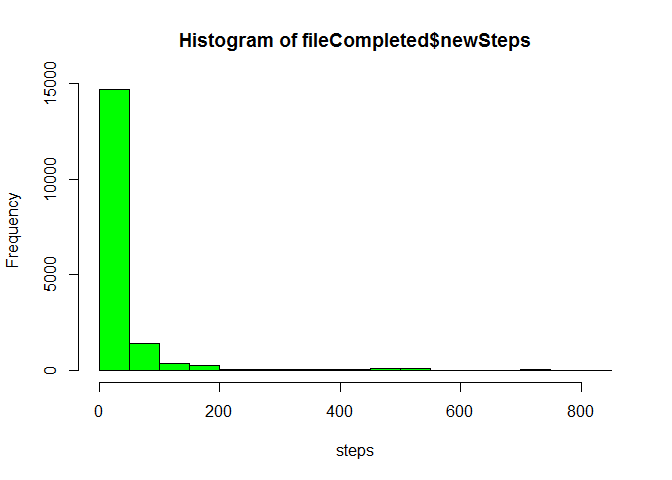

```r
hist(fileCompleted$newSteps, col ="green", xlab="steps")
```

```r
aggregate(fileCompleted$newSteps, by = list(fileCompleted$interval), FUN = mean)
```

```
##     Group.1           x
## 1         0   1.7169811
## 2         5   0.3396226
## 3        10   0.1320755
## 4        15   0.1509434
## 5        20   0.0754717
## 6        25   2.0943396
## 7        30   0.5283019
## 8        35   0.8679245
## 9        40   0.0000000
## 10       45   1.4716981
## 11       50   0.3018868
## 12       55   0.1320755
## 13      100   0.3207547
## 14      105   0.6792453
```

[output cut: 274 more lines]

```r
aggregate(fileCompleted$newSteps, by = list(fileCompleted$interval), FUN = median)
```

```
##     Group.1   x
## 1         0   0
## 2         5   0
## 3        10   0
## 4        15   0
## 5        20   0
## 6        25   0
## 7        30   0
## 8        35   0
## 9        40   0
## 10       45   0
## 11       50   0
## 12       55   0
## 13      100   0
## 14      105   0
```

[output cut: 274 more lines]

## Are there differences in activity patterns between weekdays and weekends?

For this part the weekdays() function may be of some help here. Use the dataset with the filled-in missing values for this part.

1. Create a new factor variable in the dataset with two levels - “weekday” and “weekend” indicating whether a given date is a weekday or weekend day.

```r
fileCompleted$dayType<- ifelse(weekdays(as.Date(fileCompleted$date)) %in% c("lunes","martes","miercoles","jueves","viernes"),"weekday","weekend")
head(fileCompleted)
```

```
##   interval steps       date stepsMean newSteps dayType
## 1        0    NA 2012-10-01  1.716981 1.716981 weekday
## 2        0     0 2012-11-23  1.716981 0.000000 weekday
## 3        0     0 2012-10-28  1.716981 0.000000 weekend
## 4        0     0 2012-11-06  1.716981 0.000000 weekday
## 5        0     0 2012-11-24  1.716981 0.000000 weekend
## 6        0     0 2012-11-15  1.716981 0.000000 weekday
```

2. Make a panel plot containing a time series plot (i.e. type = “l”) of the 5-minute interval (x-axis) and the average number of steps taken, averaged across all weekday days or weekend days (y-axis). See the README file in the GitHub repository to see an example of what this plot should look like using simulated data.

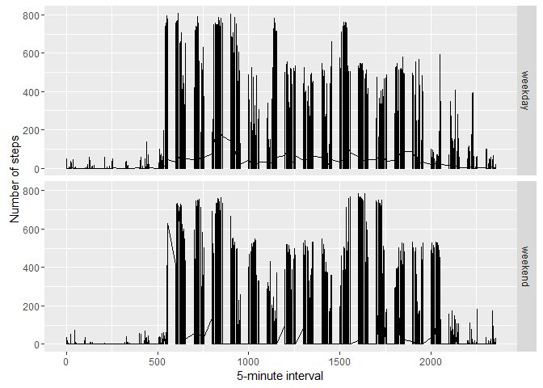

```r
fileLast <- aggregate(newSteps ~ interval + date + dayType, data=fileCompleted, mean)
ggplot(fileLast, aes(interval, newSteps)) + geom_line() + facet_grid(dayType ~ .) + xlab("5-minute interval") + ylab("Number of steps")
```